# Project 3

STATS 220 Semester One 2023

Joy Zhu

2023-05-10

## Introduction

Studying can be a mentally exhausting and quite tedious task to do, however music can help create a better environment of concentration and focus whilst making it not so boring. The genre of songs I’ve decides to explore are R&B and Kpop because in my opinion R&B song are good for nice, smooth relaxing beats, whereas Kpop is more upbeat, and energetic, which is overall a good reflection of what my i like to have while studying.

I created the playlist I wanted by using the function filter to include songs from BTS, BLACKPINK, and Daniel Caesar. By doing this I was able to analyse their music and characteristics. Additionally by using the filter applied on the release date I wanted to only include their latest songs releases in 2022 or 2019. As well I have grouped and summarized the data into average duration which shows the difference between the two genre Kpop and R&B their songs average duration, and max price where it shows by artist their tracks highest selling price. Overall by using data minipuilation like this we can modify our playlist to however we like.

| Track names: |
| --- |
| CYANIDE |
| SUPERPOSITION (feat. John Mayer) |
| FRONTAL LOBE MUZIK (feat. Pharrell Williams) |
| ARE YOU OK? |
| COMPLEXITIES |
| RESTORE THE FEELING (feat. Sean Leon & Jacob Collier) |
| OPEN UP |
| TOO DEEP TO TURN BACK |
| ENTROPY |
| Yet To Come |
| Run BTS |
| For Youth |
| Shut Down |
| Pink Venom |
| Pink Venom |

JSON allows us to look at attributes of a nested array of objects in detail as it displays the array, keys, and values. it is a very common way to store and exchange data between various computing systems APIs like iTunes.

One advantage of JSON is that it allows us to have multiple values for one key. In a dataframe, in a column, we only have one value, for example `genre` we just have one genre, however generally songs don’t just fit one genre, so if we wanted to be able to show multiple genres we could do it like this:

```json
{
  # the rest of our data would be here also
  "genre" : [
  "pop",
  "k-pop",
  "electronic"
  ]
}
```

## Key features of my playlist

```
## $19.35
```

My total came to $19.35 which is not so bad at all.

Next I was curious and wanted to know exactly how much the maximum price an the artists song was.

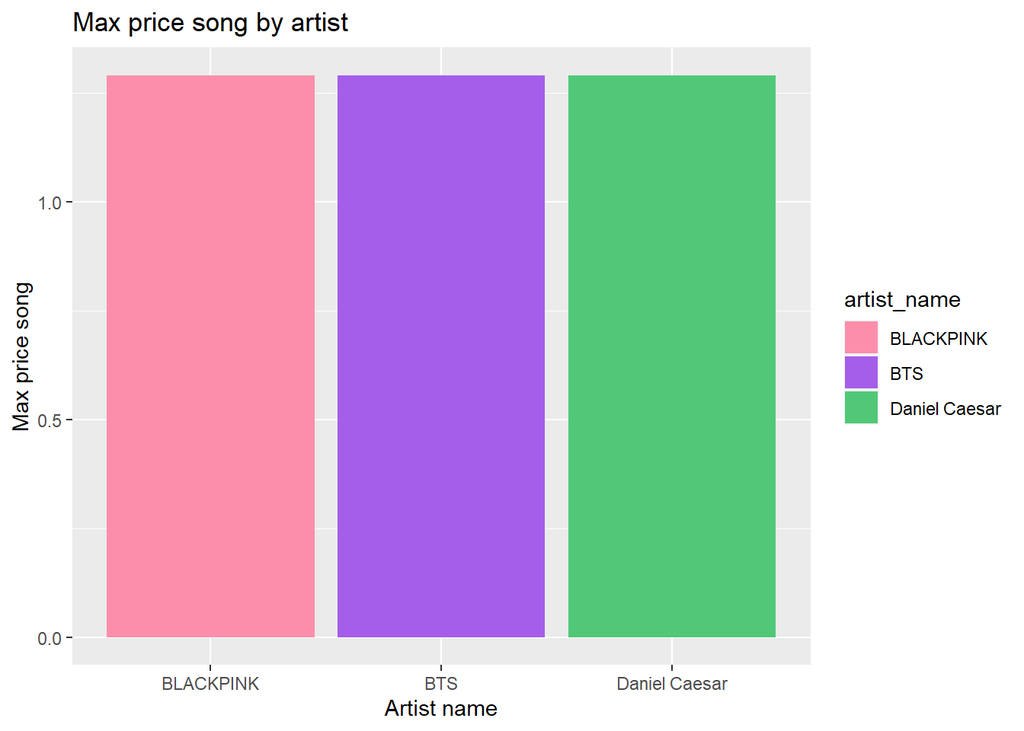

It is clear to see that all three artists have the same maximum price which makes sense since they all are popular, mainstream artists and have been around for quite some time.

Additionally I have also made a bar graph to generate a response towards the relationship between the genre and the average length of the songs.

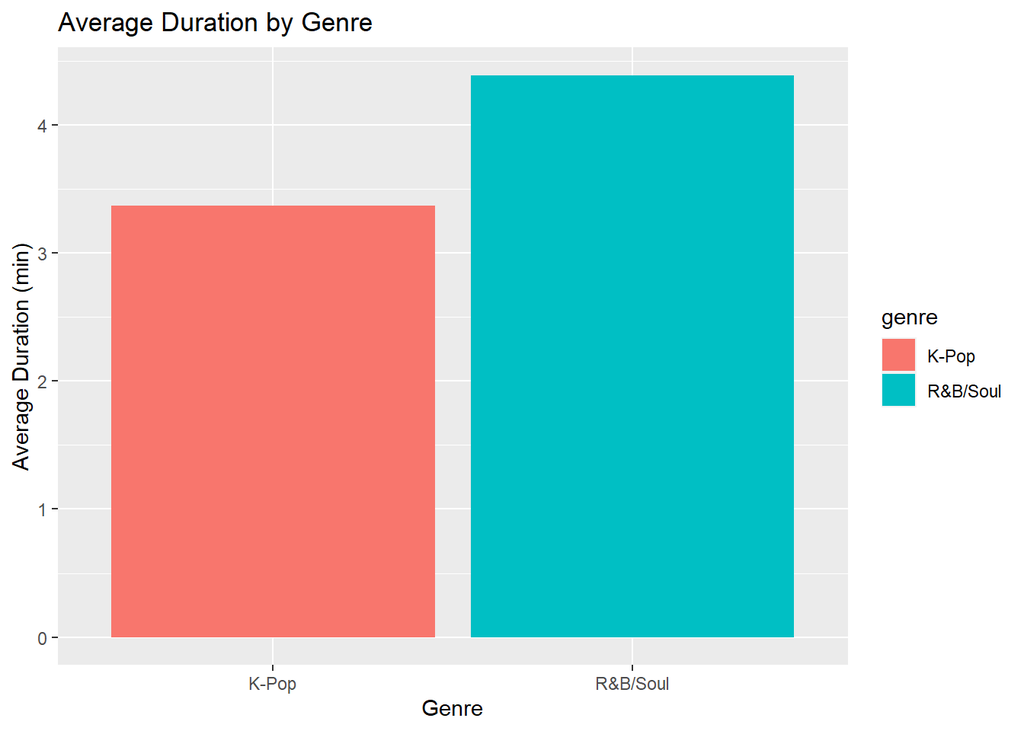

This has shown me that R&B/Soul music tend to have a higher average time in song length. I actually did expect there to be quite a gap because Kpop songs tend to be more fast, upbeat, and energetic, whereas R&B/Soul music tend to be slow, and calm.

Then I made a scatter plot to show the song price of each song and their duration.

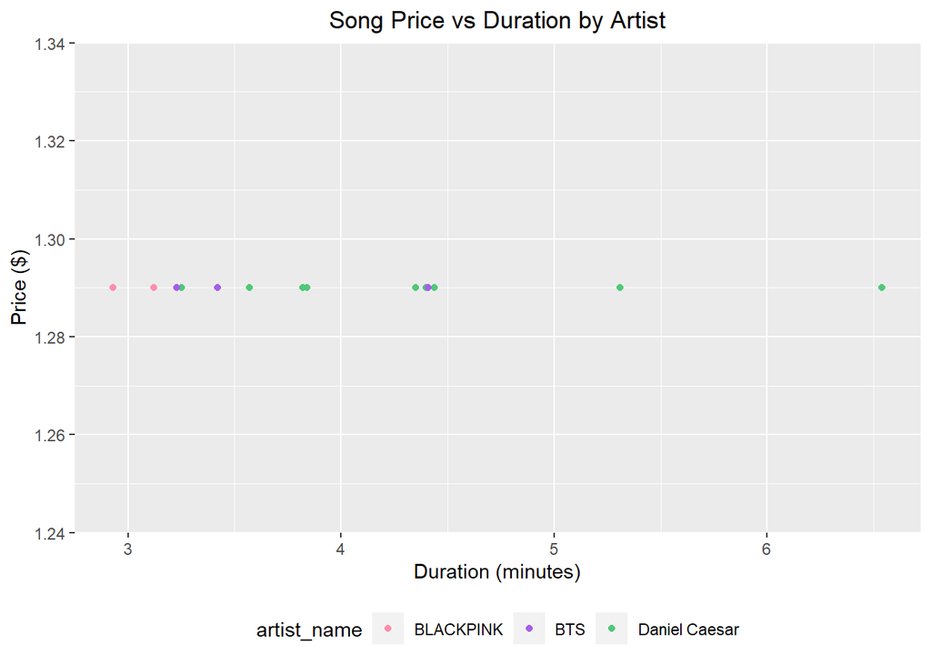

From this I can see that popular artists like BTS, BLACKPINK, and Daniel Caesar have the same song prices because popular artists tend to have higher purchases and the duration of the song tends to not matter.